# Tree-based models

# Goals

- Learn what a decision tree is, how it’s constructed and how to read one
- Understand model enhancements like bagging and boosting
- Fit a regression and classification tree on data using `caret`.
- Describe the benefits and drawbacks for using a Random Forest instead of a single Decision Tree

# Assignments

- Reading: ISLR Ch 8
- Homework: [HTML] [RMD]

# Learning - Theory

Answer the following questions. The questions are split into groups following the videos, which does not always align with numbered sections in the text.

## The Basics of Decision Trees (ISLR 8.1)

### Building Regression Trees

[[Video 1 14:37]](https://www.youtube.com/watch?v=6ENTbK3yQUQ&list=PL5-da3qGB5IB23TLuA8ZgVGC8hV8ZAdGh)

1. What does it mean to *segment* the data? What do we call this in MATH 456?
2. Are tree based methods supervised or unsupervised methods?
3. What does CART stand for?
4. What determines if a record goes to the left or right of a split? (i.e. what records go left, what go right?)
5. What do the values in the *internal* and *terminal* nodes represent?
6. How can you tell which variables are most ‘important’ in a tree model?
7. What is the *feature space*? Compare this to the term *predictor space*. Do this in your own words. You may want to look into other sources of information (outside the book) for something that fits into your mental model.
8. Explain how *recursive binary splitting* works without using equations.
9. Explain why this process has this name. That is, what about this process is *recursive*? (don’t use the word in the definition either), why *binary*?
10. Why its considered *top down* and *greedy*.
11. What is a *stopping criterion*? Give an example of one.
12. Why are decision trees considered a statistical *learning* model? Where does the algorithmic learning occur?

### Pruning Trees

[[Video 2 11:45]](https://www.youtube.com/watch?v=GfPR7Xhdokc&list=PL5-da3qGB5IB23TLuA8ZgVGC8hV8ZAdGh&index=2)

1. How are predictions of new values made?
2. Why is pruning necessary? Why can’t we just build a short tree by stopping early?
3. How is *Cost complexity pruning* similar to LASSO?
4. What is the penalty function? Report this in symbols, not words, but define each symbol in words.
5. How is $\alpha$ chosen?
6. What information do you get out of Figure 8.5? If you were to build this plot as part of your analysis (just the black and green lines), what information can you draw from it?

## Classification Trees (ISLR 8.1.2)

[[Video 3 11:00]](https://www.youtube.com/watch?v=hPEJoITBbQ4&list=PL5-da3qGB5IB23TLuA8ZgVGC8hV8ZAdGh&index=3)

1. How do you make predictions from a classification tree?
2. What is the *classification error rate*?
3. What does *node purity* mean? Why is it important (it may be helpful to read through the example before answering this question).
4. Is a large or small *Gini index* preferred?
5. If prediction accuracy is the goal of tree building, what measure should be used to prune the tree?

## Advantages and Disadvantages of Trees (ISLR 8.1.4)

1. Name one advantage and disadvantage of trees when compared to classical methods.

## Bagging, Random Forests, Boosting (ISLR 8.2)

### Bagging (ISLR 8.2.1)

[[Video 13:45]](https://www.youtube.com/watch?v=lq_xzBRIWm4&list=PL5-da3qGB5IB23TLuA8ZgVGC8hV8ZAdGh&index=4)

1. Bagging is a general-purpose procedure for reducing (bias or variance?) of a statistical learning method
2. Explain how bagging works.
3. What is a *majority vote* in the context of classification?
4. What is an out of bag error estimate? How does it compare to k-fold CV/LOOCV?

### Random Forests

1. What’s the main difference between building a Random Forest vs simply bagged trees?
2. How is the Gini index used to generate a summary measure of importance for each predictor in a Random Forest?
3. In the gene expression example (video), what critiera do they use to pre-screen variables to go into the model, and why?
4. Why can we say that Random Forests is equivlenant to bagging trees when $m=p$?
5. Can you overfit a Random Forest model by constructing too many trees?

### Boosting (ISLR 8.2.3)

[[Video 12:02]](https://www.youtube.com/watch?v=U3MdBNysk9w&list=PL5-da3qGB5IB23TLuA8ZgVGC8hV8ZAdGh&index=5)

1. How is boosting a sequential method?
2. In Boosting, why are the trees are grown on the residuals?
3. What are the three tuning parameters for boosting?

# Learning - Application

Explore tree based models using the UCI data from the prior assignment.

```r
library(dplyr)
library(ggplot2)
library(rpart)       # direct engine for decision tree application
library(caret)       # meta engine for machine learning

load("breast_cancer_UCI.Rdata")
```

Recall this is a dataset with continuous measurements on breast tumors, with a categorical response variable of either `B`enign or `M`alignant.

## Preprocess data

Split into testing/training. Set train control parameters (5 fold CV), and preprocessing steps (normalizing the data).

```r
train.idx <- createDataPartition(bc$diagnosis, p = .6, list = FALSE)

train.dta <- bc[train.idx,]
test.dta  <- bc[-train.idx,]

fitControl <- trainControl(method="cv", number=5)
PreProc    <- c("center", "scale")
```

## Decision Trees

### 1. Build and prune a tree

Using the `rpart` method (recursive partioning). Requires the `rpart` package.

```r
bc.tree <- train(diagnosis ~ .,
                  data=train.dta,
                  method="rpart",
                  trControl = fitControl,
                  preProcess = PreProc)
```

The basic output shows a recap of what the data looks like (n, p, classes), the preprocessing and resampling processes, as well as the tuning parameters and which were chosen to use in the final model.

```r
bc.tree
```

```
## CART
##
## 343 samples
##  30 predictor
##   2 classes: 'B', 'M'
##
## Pre-processing: centered (30), scaled (30)
## Resampling: Cross-Validated (5 fold)
## Summary of sample sizes: 275, 274, 275, 274, 274
## Resampling results across tuning parameters:
##
##   cp         Accuracy   Kappa
##   0.0078125  0.9183717  0.8230605
##   0.0468750  0.9067349  0.7991120
##   0.8046875  0.7790708  0.4463397
##
## Accuracy was used to select the optimal model using the largest value.
## The final value used for the model was cp = 0.0078125.
```

The tuning parameter `cp` stands for *complexity parameter* and that’s what controls the pruning. The default is to evaluate 3 values for `cp`, we can change this in the `tuneLength` argument to evaluate more, say 7.

```r
bc.tree <- train(diagnosis ~ .,
                  data=train.dta,
                  method="rpart",
                  tuneLength= 7,
                  trControl = fitControl,
                  preProcess = PreProc)
```

Plotting this object gives you a summary of the cross-validated model complexity.

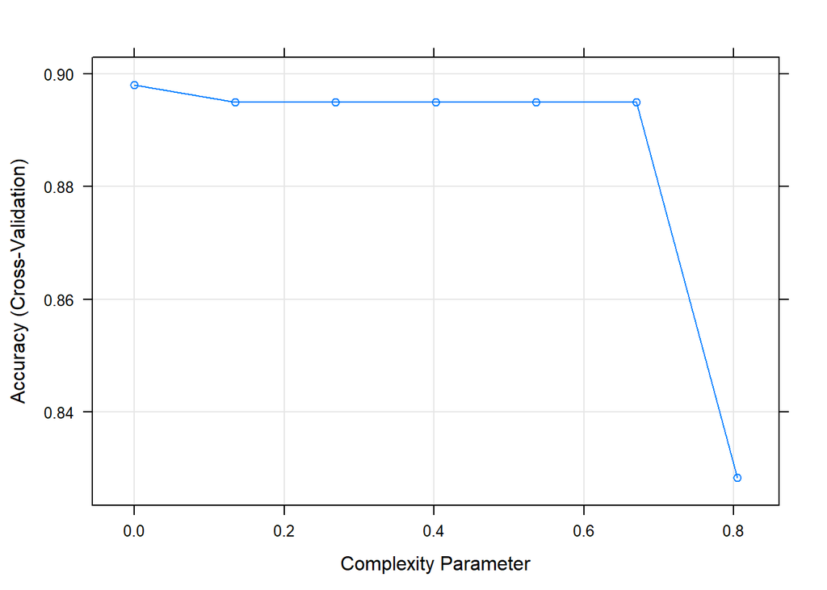

```r
plot(bc.tree)
```

Calling a `summary` on the tree object would gives us more information.

```r
summary(bc.tree)
```

[output not shown]

[output cut: 2928 more lines]

```
##
## Node number 7: 104 observations
##   predicted class=M  expected loss=0  P(node) =0.303207
##     class counts:     0   104
##    probabilities: 0.000 1.000
##
## Node number 10: 13 observations
##   predicted class=B  expected loss=0.1538462  P(node) =0.03790087
##     class counts:    11     2
##    probabilities: 0.846 0.154
##
## Node number 11: 14 observations
##   predicted class=M  expected loss=0.07142857  P(node) =0.04081633
##     class counts:     1    13
##    probabilities: 0.071 0.929
```

A *lot* more. Specifically it is showing [1] the data set (not ideal with large datasets), [2] the variable importance measures, and [3] information on each node such as what the splits were, how many observations are to either side of the split, and the predicted probability of the outcome for that node.

Let’s see how to get this information out in a more concise manner. Like plotting the final tree!

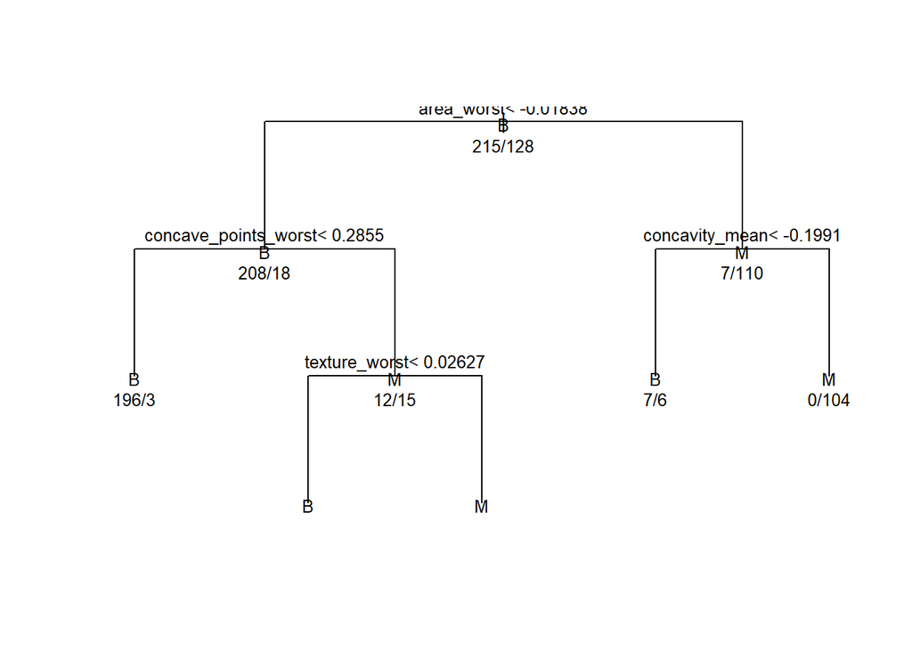

```r
plot(bc.tree$finalModel, uniform=TRUE)
text(bc.tree$finalModel, use.n = TRUE, all=TRUE, cex=.8)
```

How about a fancier version? Perhaps more readable? Let’s use the `rpart.plot` function in the similarly named `rpart.plot` package. The full package information can be found ere: http://www.milbo.org/rpart-plot/

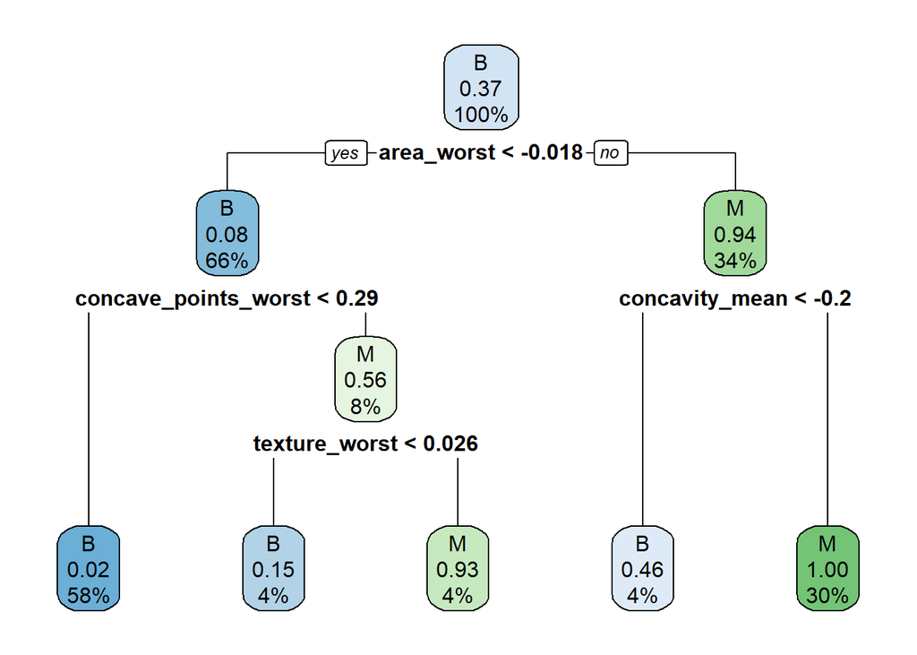

```r
rpart.plot::rpart.plot(bc.tree$finalModel)
```

Okay prettier, but what does the information in the box mean?

Let’s look at the top box as a demonstration.

- `B`: The predicted class for observations falling into that node
- `0.37`: The predicted probability of the outcome (here we are predicting `M`)
- `100%`: The percent of observations that are in that node.

### 2. Predict using the tree

Create the prediction using `predict`, and add it back onto the testing dataset so we can do some easier comparisons.

```r
test.dta$pred.class <- bc.tree %>% predict(test.dta)
confusionMatrix(test.dta$diagnosis, test.dta$pred.class)
```

```
## Confusion Matrix and Statistics
##
##           Reference
## Prediction   B   M
##          B 140   2
##          M  10  74
##
##                Accuracy : 0.9469
##                  95% CI : (0.9091, 0.9723)
##     No Information Rate : 0.6637
##     P-Value [Acc > NIR] : < 2e-16
##
##                   Kappa : 0.8841
##
##  Mcnemar's Test P-Value : 0.04331
##
##             Sensitivity : 0.9333
##             Specificity : 0.9737
##          Pos Pred Value : 0.9859
##          Neg Pred Value : 0.8810
##              Prevalence : 0.6637
##          Detection Rate : 0.6195
##    Detection Prevalence : 0.6283
##       Balanced Accuracy : 0.9535
##
##        'Positive' Class : B
##
```

## Random Forests

Fit the tree using no additional options and the `rf` method. Upon reading up on new methods, looks like [[ranger]](https://github.com/imbs-hl/ranger) might be a really good upgrade at this time.

```r
rf.tree <- train(diagnosis ~ .,
                  data=train.dta,
                  method="rf",
                  trControl = fitControl,
                  preProcess = PreProc)
rf.tree
```

```
## Random Forest
##
## 343 samples
##  30 predictor
##   2 classes: 'B', 'M'
##
## Pre-processing: centered (30), scaled (30)
## Resampling: Cross-Validated (5 fold)
## Summary of sample sizes: 274, 275, 274, 274, 275
## Resampling results across tuning parameters:
##
##   mtry  Accuracy   Kappa
##    2    0.9503836  0.8933060
##   16    0.9473998  0.8871106
##   30    0.9503410  0.8930780
##
## Accuracy was used to select the optimal model using the largest value.
## The final value used for the model was mtry = 2.
```

Plotting the model object gives us the CV accuracy for the only tuning parameter the rf method allows for, `mtry`, or the number of randomly selected predictors chosen at each node. This matches the output above that shows only choosing 2 variables for each split results in the best CV accuracy.

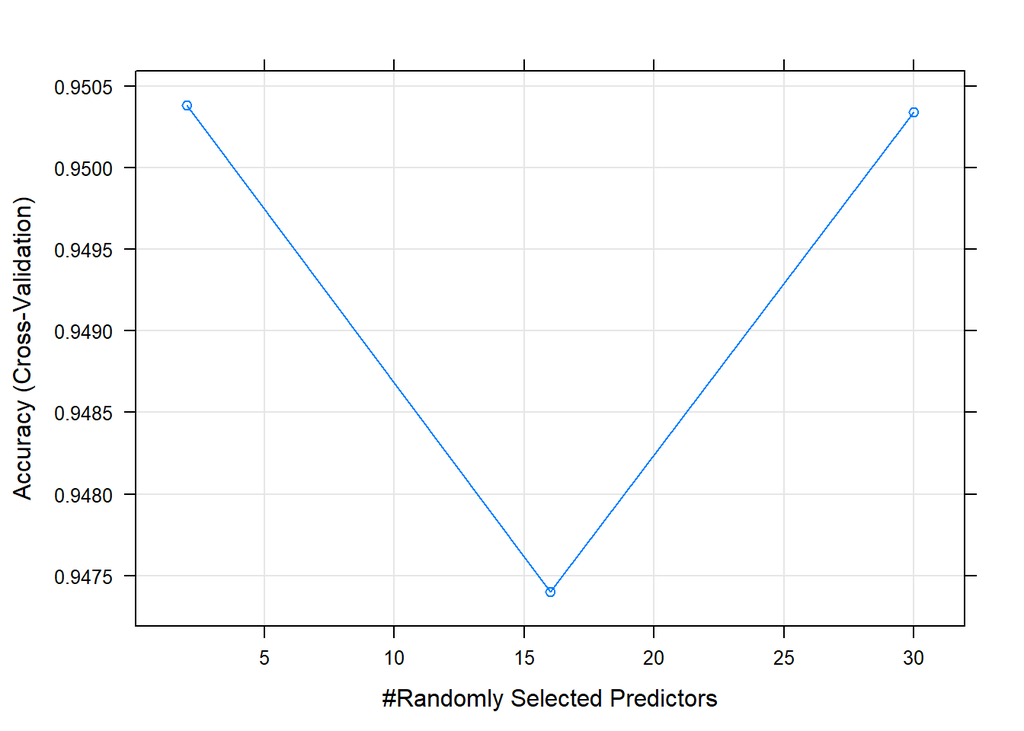

```r
plot(rf.tree)
```

Variable importance: Which predictors contribute to the ‘best’ prediction?

```r
varImp(rf.tree)
```

```
## rf variable importance
##
##   only 20 most important variables shown (out of 30)
##
##                      Overall
## radius_worst          100.00
## perimeter_worst        99.34
## concavity_mean         87.98
## concave_points_mean    86.28
## area_worst             78.77
## concave_points_worst   73.53
## area_mean              52.96
## concavity_worst        51.86
## radius_mean            51.77
## perimeter_mean         49.32
## area_se                39.30
## compactness_worst      28.38
## texture_worst          26.65
## radius_se              23.12
## compactness_mean       19.94
## texture_mean           17.34
## perimeter_se           16.47
## smoothness_worst       15.33
## concave_points_se      13.28
## concavity_se           11.60
```

# Additional Resources

- http://www.milbo.org/rpart-plot/
- http://www.sthda.com/english/articles/35-statistical-machine-learning-essentials/141-cart-model-decision-tree-essentials/

## Random Forests

- https://bradleyboehmke.github.io/HOML/random-forest.html
- https://topepo.github.io/caret/train-models-by-tag.html#random-forest
- https://uc-r.github.io/random_forests
- https://cran.rstudio.com/web/packages/randomForestExplainer/vignettes/randomForestExplainer.html

## Variable Importance

- https://koalaverse.github.io/vip/articles/vip.html